# Social Care Survey Open Data

Simple descriptive analysis

# 1 Introduction

Plot to compare number of over 65s per 1000 population receiving social care.

Based on 2012 Social Care Survey Open Data. The offical report plots per thousand population receiving home care but for the whole population - let’s concentrate on over 65s.

## 1.1 Load data

```r
load("produced_data/created_objects/soc_care12.rds")

# This object is the cleaned version of the 2012 social care survey and was created in the file ("reports/01-import_and_tidy.html") or raw rmarkdown can be found ("rmds/import_and_tidy.Rmd")
```

## 1.2 Load packages

```r
library(readr)
library(dplyr)
library(tidyr)
library(purrr)
library(forcats)
library(stringr)
library(ggplot2)
library(ggthemes)
library(extrafont)
theme_set(theme_tufte(base_size = 12))
ubdc_palette <- c("#13AFD6", "#E6E600", "#F07329", "#35B14E", "#D7509A", "#2165AF",
                  "#BCD032","#866BAC", "#545A5D",  "#7A8082", "#E2D988", "#628DB7",
                  "#929B9A", "#93B8DA", "#31649B", "#FBF8D0", "#ACB2B4", "#D1DAE2")
```

# 2 Overall numbers

1st thing is to look at the overall numbers of records returned for each local autority area.

```r
#summarise overall data first
total_summary_2012 <-
  soc_care12 %>%
  filter(age_grp != "18-<65") %>%  #drop those under 65
  group_by(council) %>%
  summarise(N_total = n()) %>%
  mutate(freq_total = N_total / sum(N_total),
         pct_total = round((freq_total * 100), 1))

#summarise homecare only data now
home_care_summary_2012 <-
  soc_care12 %>%
  filter(age_grp != "18-<65") %>%  #drop those under 65
  filter(hc_client == "Yes") %>%   #drop non-home care clients
  group_by(council) %>%
  summarise(N_homecare = n()) %>%
  mutate(freq_homecare = N_homecare / sum(N_homecare),
         pct_homecare = round((freq_homecare * 100), 1))

#and finally, summarise telecare only data
telecare_summary_2012 <-
  soc_care12 %>%
  filter(age_grp != "18-<65") %>%  #drop those under 65
  filter(hc_client == "No") %>%   #keep only non-home care clients
  group_by(council) %>%
  summarise(N_telecare = n()) %>%
  mutate(freq_telecare = N_telecare / sum(N_telecare),
         pct_telecare = round((freq_telecare * 100), 1))

#Join these table together

summary_2012_table <-
  left_join(total_summary_2012, home_care_summary_2012) %>%
  left_join(., telecare_summary_2012)
summary_2012_table
```

| council | N_total | freq_total | pct_total | N_homecare | freq_homecare | pct_homecare | N_telecare | freq_telecare | pct_telecare |
| --- | --- | --- | --- | --- | --- | --- | --- | --- | --- |
| Aberdeen City | 2969 | 0.025584902 | 2.6 | 1784 | 0.034899644 | 3.5 | 1185 | 0.018251267 | 1.8 |
| Aberdeenshire | 3308 | 0.028506183 | 2.9 | 1828 | 0.035760398 | 3.6 | 1480 | 0.022794831 | 2.3 |
| Angus | 3643 | 0.031392994 | 3.1 | 1326 | 0.025939982 | 2.6 | 2317 | 0.035686232 | 3.6 |
| Argyll & Bute | 1774 | 0.015287173 | 1.5 | 836 | 0.016354317 | 1.6 | 938 | 0.014446994 | 1.4 |
| Clackmannanshire | 1317 | 0.011349046 | 1.1 | 546 | 0.010681169 | 1.1 | 771 | 0.011874875 | 1.2 |
| Dumfries & Galloway | 3171 | 0.027325606 | 2.7 | 1993 | 0.038988223 | 3.9 | 1178 | 0.018143453 | 1.8 |
| Dundee City | 4991 | 0.043009177 | 4.3 | 1614 | 0.031574005 | 3.2 | 3377 | 0.052012260 | 5.2 |
| East Ayrshire | 3086 | 0.026593132 | 2.7 | 1632 | 0.031926132 | 3.2 | 1454 | 0.022394381 | 2.2 |
| East Dunbartonshire | 2208 | 0.019027102 | 1.9 | 963 | 0.018838765 | 1.9 | 1245 | 0.019175382 | 1.9 |
| East Lothian | 1353 | 0.011659270 | 1.2 | 1175 | 0.022986032 | 2.3 | 178 | 0.002741540 | 0.3 |

[output cut: 22 more lines]

```r
rm(list = c("home_care_summary_2012", "total_summary_2012", "telecare_summary_2012"))
```

Now we can plot these

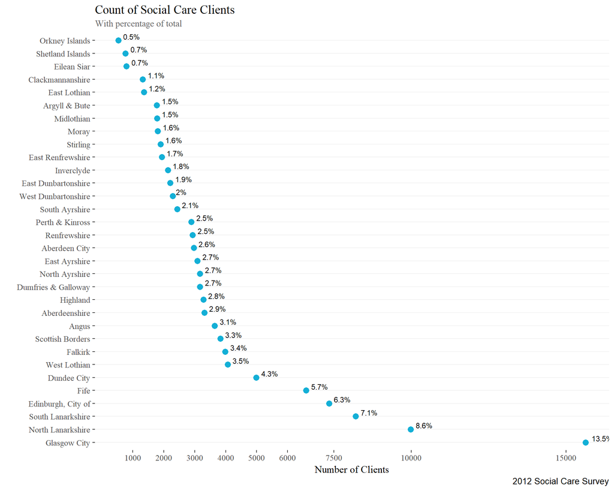

```r
ggplot(summary_2012_table, aes(reorder(council, -N_total), N_total)) +
  geom_point(color = ubdc_palette[1], size = 3) +
  geom_text(aes(label=paste0(pct_total,"%")), size = 3, hjust = -0.3, vjust = -0.2) +
  scale_y_continuous(breaks = c(1000, 2000, 3000, 4000, 5000, 6000, 7500, 10000, 15000)) +
  theme(plot.subtitle = element_text(color = "#666666"),
        plot.caption = element_text("#AAAAAA", size = 10),
        panel.grid.major.y = element_line(colour = "#f2f2f2")) +
  labs(
    title = "Count of Social Care Clients",
    subtitle = "With percentage of total",
    x = "",
    y = "Number of Clients",
    caption = "2012 Social Care Survey") +
  coord_flip()
```

And repeat for **only** home care clients

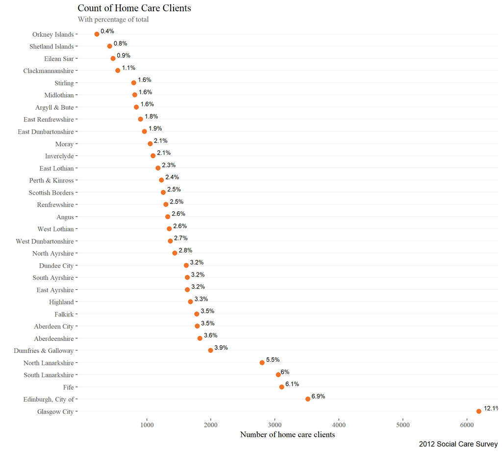

```r
ggplot(summary_2012_table, aes(reorder(council, -N_homecare), N_homecare)) +
  geom_point(color = ubdc_palette[3], size = 3) +
  geom_text(aes(label=paste0(pct_homecare,"%")), size=3, hjust = -0.3, vjust = -0.2) +
  scale_y_continuous(breaks = c(1000, 2000, 3000, 4000, 5000, 6000, 7500, 10000, 15000)) +
  theme(plot.subtitle = element_text(color = "#666666"),
        plot.caption = element_text("#AAAAAA", size = 10),
        panel.grid.major.y = element_line(colour = "#f2f2f2")) +
  labs(
    title = "Count of Home Care Clients",
    subtitle = "With percentage of total",
    x = "",
    y = "Number of home care clients",
    caption = "2012 Social Care Survey") +
  coord_flip()
```

And non-home care clients i.e. telecare or other services only

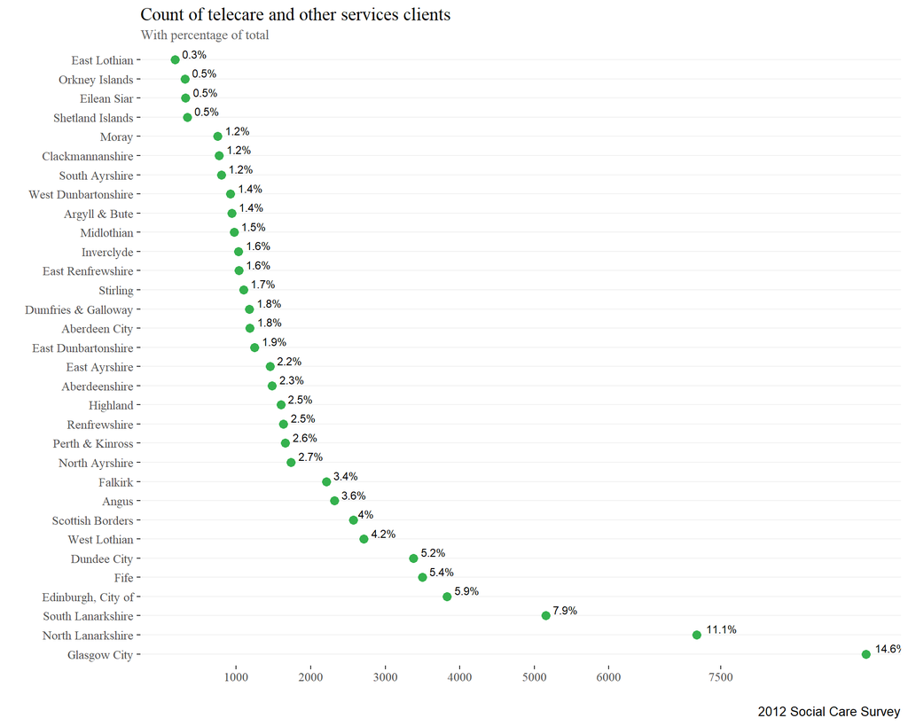

```r
ggplot(summary_2012_table, aes(reorder(council, -N_telecare), N_telecare)) +
  geom_point(color = ubdc_palette[4], size = 3) +
  geom_text(aes(label=paste0(pct_telecare,"%")), size=3, hjust = -0.3, vjust = -0.2) +
  scale_y_continuous(breaks = c(1000, 2000, 3000, 4000, 5000, 6000, 7500, 10000, 15000)) +
  theme(plot.subtitle = element_text(color = "#666666"),
        plot.caption = element_text("#AAAAAA", size = 10),
        panel.grid.major.y = element_line(colour = "#f2f2f2")) +
  labs(
    title = "Count of telecare and other services clients",
    subtitle = "With percentage of total",
    x = "",
    y = "",
    caption = "2012 Social Care Survey") +
  coord_flip()
```

# 3 Population Proportions

## 3.1 Import and tidy census data

To calculate proportions of over 65s getting care in each local authority we need the total number of over 65s in that LA.

For this I am going to use the 2011 Population estimates downloaded from the National Records of Scotland here:- https://www.nrscotland.gov.uk/statistics-and-data/statistics/statistics-by-theme/population/2011-census-reconciliation-report/list-of-tables

This data needs imported and cleaned.

I’m going to create `pop_data_combined`: a `data_frame` with population sizes of each Local Authority as a total and for over 65s

```r
#Note I cheated and converted data to numeric in excel to remove the commas as 1000 seperators

#import and tidy raw data
pop_data <- read_csv("raw_data/2011-cen-rec-report-pop-tab1b.csv", skip = 3) %>%
  slice(1:34) %>%
  filter(X1 %in% c("Council areas", "SCOTLAND") == FALSE) %>%
  select(-X3, -X23, -X24) %>%
  map_at(2:21, as.numeric) %>% #coerce from character to numeric
  as_data_frame()

names(pop_data) <- str_replace(names(pop_data), "X1", "council") #rename X variables
names(pop_data) <- str_replace(names(pop_data), "X2", "total")

#tidy data for manipulation
pop_data_2011 <-
  pop_data %>%
  gather(age_grp, value, 2:21) %>%
  arrange(council)

#create table of total population per council
pop_data_total <-
  pop_data_2011 %>%
  filter(age_grp == "total") %>%
  select(-age_grp) %>%
  arrange(council)
names(pop_data_total) <- str_replace(names(pop_data_total), "value", "pop_total")

#create table of total over65s per council
pop_data_65plus <-
  pop_data_2011 %>%
  filter(age_grp %in% c("65 - 69", "70 - 74", "75 - 79", "80 - 84", "85 - 89",
                        "90+") == TRUE) %>%
  group_by(council) %>%
  mutate(pop_over_65 = sum(value)) %>%
  arrange(council) %>%
  select(council, pop_over_65) %>%
  unique(.)

#join tables together
pop_data_combined_2011 <-
  full_join(pop_data_total, pop_data_65plus)

pop_data_combined_2011
```

| council | pop_total | pop_over_65 |
| --- | --- | --- |
| Aberdeen City | 222793 | 32031 |
| Aberdeenshire | 252973 | 40663 |
| Angus | 115978 | 23061 |
| Argyll & Bute | 88166 | 19336 |
| Clackmannanshire | 51442 | 8212 |
| Dumfries & Galloway | 151324 | 33050 |
| Dundee City | 147268 | 24597 |
| East Ayrshire | 122767 | 21307 |
| East Dunbartonshire | 105026 | 20428 |
| East Lothian | 99717 | 17763 |

[output cut: 22 more lines]

```r
rm(list = c("pop_data_65plus", "pop_data_total", "pop_data"))
```

## 3.2 Join to social care data

Ok, now to join together the population and social care summaries.

```r
summary_2012_table <-
  left_join(pop_data_combined_2011, summary_2012_table)
#refactorise council
summary_2012_table$council <- as.factor(summary_2012_table$council)

#drop the total population column - we don't need it and it could get confusing

summary_2012_table <- select(summary_2012_table, -pop_total)

summary_2012_table
```

| council | pop_over_65 | N_total | freq_total | pct_total | N_homecare | freq_homecare | pct_homecare | N_telecare | freq_telecare | pct_telecare |
| --- | --- | --- | --- | --- | --- | --- | --- | --- | --- | --- |
| Aberdeen City | 32031 | 2969 | 0.025584902 | 2.6 | 1784 | 0.034899644 | 3.5 | 1185 | 0.018251267 | 1.8 |
| Aberdeenshire | 40663 | 3308 | 0.028506183 | 2.9 | 1828 | 0.035760398 | 3.6 | 1480 | 0.022794831 | 2.3 |
| Angus | 23061 | 3643 | 0.031392994 | 3.1 | 1326 | 0.025939982 | 2.6 | 2317 | 0.035686232 | 3.6 |
| Argyll & Bute | 19336 | 1774 | 0.015287173 | 1.5 | 836 | 0.016354317 | 1.6 | 938 | 0.014446994 | 1.4 |
| Clackmannanshire | 8212 | 1317 | 0.011349046 | 1.1 | 546 | 0.010681169 | 1.1 | 771 | 0.011874875 | 1.2 |
| Dumfries & Galloway | 33050 | 3171 | 0.027325606 | 2.7 | 1993 | 0.038988223 | 3.9 | 1178 | 0.018143453 | 1.8 |
| Dundee City | 24597 | 4991 | 0.043009177 | 4.3 | 1614 | 0.031574005 | 3.2 | 3377 | 0.052012260 | 5.2 |
| East Ayrshire | 21307 | 3086 | 0.026593132 | 2.7 | 1632 | 0.031926132 | 3.2 | 1454 | 0.022394381 | 2.2 |
| East Dunbartonshire | 20428 | 2208 | 0.019027102 | 1.9 | 963 | 0.018838765 | 1.9 | 1245 | 0.019175382 | 1.9 |
| East Lothian | 17763 | 1353 | 0.011659270 | 1.2 | 1175 | 0.022986032 | 2.3 | 178 | 0.002741540 | 0.3 |

[output cut: 22 more lines]

## 3.3 Calculate proportions per population

Finally, I’m going to calculate the per thousand proportions.

```r
per_thousand_table <-
  summary_2012_table %>%
  mutate(any_care_per_thousand = (round((N_total / pop_over_65) * 1000, 1)),
         homecare_per_thousand = (round((N_homecare / pop_over_65) * 1000, 1)),
         telecare_per_thousand = (round((N_telecare / pop_over_65) * 1000, 1))) %>%
  select(council, any_care_per_thousand, homecare_per_thousand, telecare_per_thousand)
per_thousand_table
```

| council | any_care_per_thousand | homecare_per_thousand | telecare_per_thousand |
| --- | --- | --- | --- |
| Aberdeen City | 92.7 | 55.7 | 37.0 |
| Aberdeenshire | 81.4 | 45.0 | 36.4 |
| Angus | 158.0 | 57.5 | 100.5 |
| Argyll & Bute | 91.7 | 43.2 | 48.5 |
| Clackmannanshire | 160.4 | 66.5 | 93.9 |
| Dumfries & Galloway | 95.9 | 60.3 | 35.6 |
| Dundee City | 202.9 | 65.6 | 137.3 |
| East Ayrshire | 144.8 | 76.6 | 68.2 |
| East Dunbartonshire | 108.1 | 47.1 | 60.9 |
| East Lothian | 76.2 | 66.1 | 10.0 |

[output cut: 22 more lines]

## 3.4 Save objects

I’m going to save the objects created so far.

```r
save(summary_2012_table, file = "produced_data/created_objects/summary_2012_table.rds")
save(pop_data_2011, file = "produced_data/created_objects/pop_data_2011.rds")
save(pop_data_combined_2011, file = "produced_data/created_objects/pop_data_combined_2011.rds")
save(per_thousand_table, file = "produced_data/created_objects/per_thousand_table.rds")
```

# 4 Plots

## 4.1 Any social care

Finally! Let’s take a look

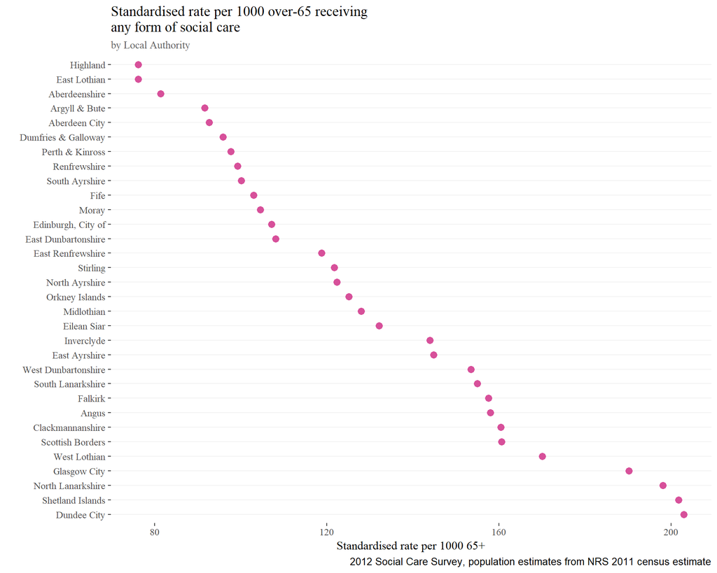

```r
ggplot(per_thousand_table,
       aes(x = reorder(council, -any_care_per_thousand),
           y = any_care_per_thousand)) +
  geom_point(color = ubdc_palette[5], size = 3) +
  theme(plot.subtitle = element_text(color = "#666666"),
        plot.caption = element_text("#AAAAAA", size = 10),
        panel.grid.major.y = element_line(colour = "#f2f2f2")) +
  labs(
    title = "Standardised rate per 1000 over-65 receiving\nany form of social care",
    subtitle = "by Local Authority",
    x = "",
    y = "Standardised rate per 1000 65+",
    caption = "2012 Social Care Survey, population estimates from NRS 2011 census estimate") +
  coord_flip()
```

Just to check that missing data isn’t accounting for the variation….

```r
missing <-
  soc_care12 %>%
  group_by(council, age_grp) %>%
  tally() %>%
  filter(is.na(age_grp))
missing
```

| council | age_grp | n |
| --- | --- | --- |
| Argyll & Bute | NA | 6 |
| Edinburgh, City of | NA | 108 |
| Eilean Siar | NA | 26 |
| Glasgow City | NA | 10 |
| Highland | NA | 1152 |
| Midlothian | NA | 12 |
| Moray | NA | 6 |
| Perth & Kinross | NA | 1 |
| Scottish Borders | NA | 1 |
| Shetland Islands | NA | 6 |

[output cut: 2 more lines]

So with the exception of Highland, no area has a significant amount of missing data to majorly skew results.

I’m going to remove Highland fromt the overall plot. It is likely a lot of their missing data is for over 65s.

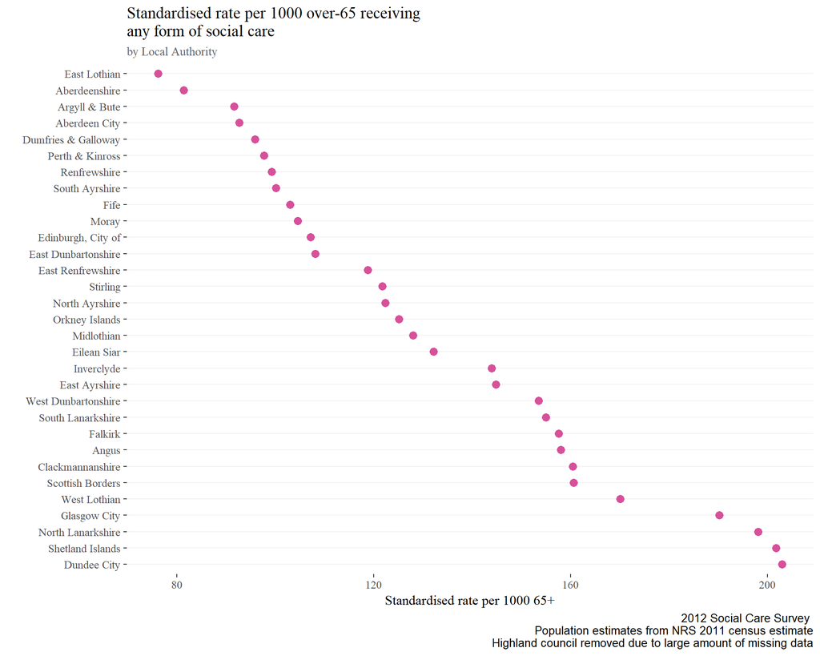

```r
per_thousand_table %>%
  filter(council != "Highland") %>%
  ggplot(.,
       aes(x = reorder(council, -any_care_per_thousand),
           y = any_care_per_thousand)) +
  geom_point(color = ubdc_palette[5], size = 3) +
  theme(plot.subtitle = element_text(color = "#666666"),
        plot.caption = element_text("#AAAAAA", size = 10),
        panel.grid.major.y = element_line(colour = "#f2f2f2")) +
  labs(
    title = "Standardised rate per 1000 over-65 receiving\nany form of social care",
    subtitle = "by Local Authority",
    x = "",
    y = "Standardised rate per 1000 65+",
    caption = "2012 Social Care Survey \nPopulation estimates from NRS 2011 census estimate\nHighland council removed due to large amount of missing data") +
  coord_flip()
```

## 4.2 Home care only

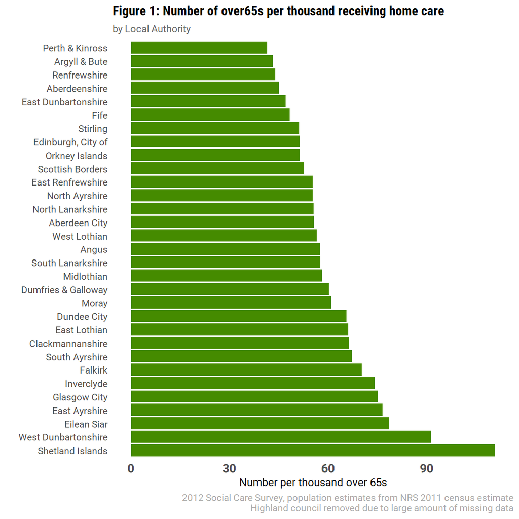

```r
homecare_plot<-
  per_thousand_table %>%
  filter(council != "Highland") %>%
  ggplot(.,
       aes(x = reorder(council, -homecare_per_thousand),
           y = homecare_per_thousand)) +
  geom_col(fill = "chartreuse4") +
  labs(
    title = "Figure 1: Number of over65s per thousand receiving home care",
    subtitle = "by Local Authority",
    x = "",
    y = "Number per thousand over 65s",
    caption = "2012 Social Care Survey, population estimates from NRS 2011 census estimate
    Highland council removed due to large amount of missing data") +
  theme_minimal(base_size=9, base_family="Roboto") +
    theme(plot.subtitle = element_text(color="#666666"),
          plot.title = element_text(family="Roboto Condensed", face = "bold"),
          plot.caption = element_text(color="#AAAAAA", size=8),
          axis.text.y = element_text(size = 8),
          axis.text.x = element_text(size = 10, face = "bold")) +
  coord_flip()
homecare_plot
```

Save this plot (for UBDC blog!)

```r
ggsave("plots/over65s_homecare.png", homecare_plot, width=6, height=6)
```

## 4.3 Telecare only

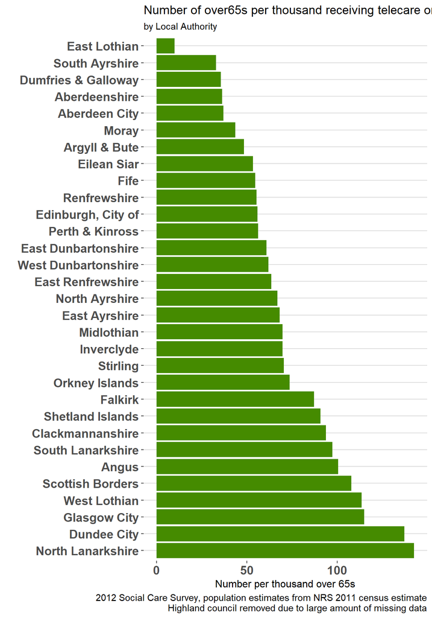

```r
per_thousand_table %>%
  filter(council != "Highland") %>%
  ggplot(.,
       aes(x = reorder(council, -telecare_per_thousand),
           y = telecare_per_thousand)) +
  geom_col(fill = "chartreuse4") +
  theme(axis.text.y = element_text(size = 14, face = "bold")) +
  theme(axis.text.x = element_text(size = 14, face = "bold")) +
  theme_hc() +
  labs(
    title = "Number of over65s per thousand receiving telecare or other services only",
    subtitle = "by Local Authority",
    x = "",
    y = "Number per thousand over 65s",
    caption = "2012 Social Care Survey, population estimates from NRS 2011 census estimate
    Highland council removed due to large amount of missing data") +
  coord_flip()
```

# 5 Alternative UBDC blog plot

Going to try a Clevland dotplot.

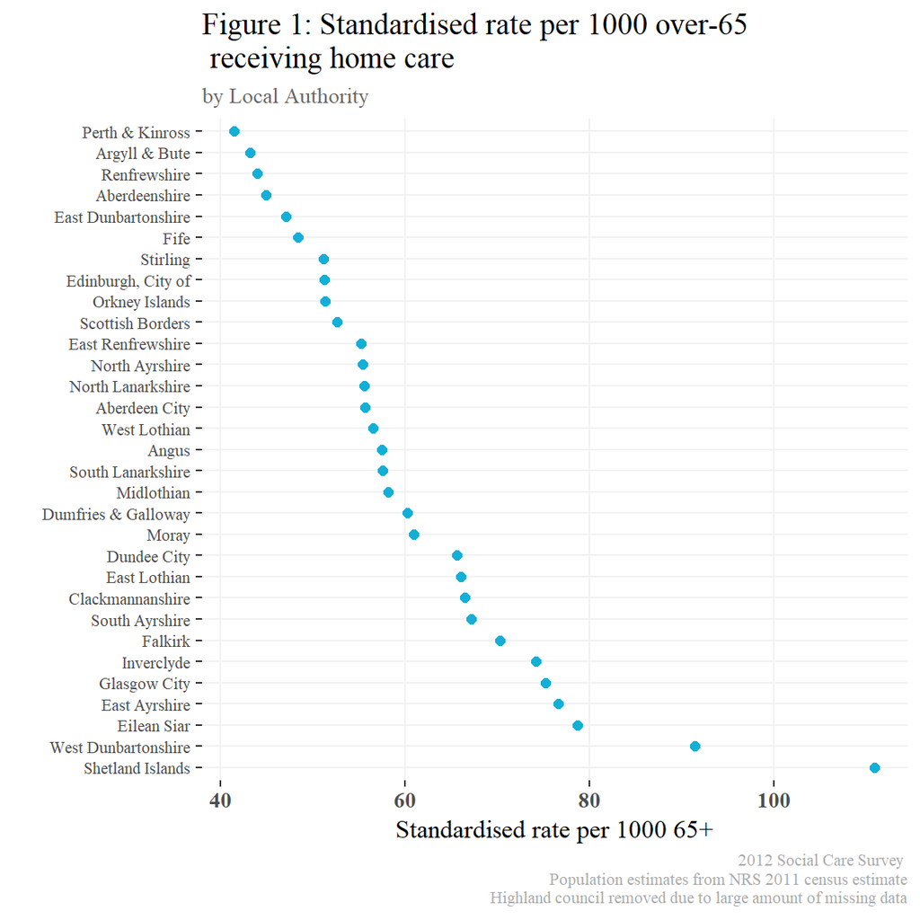

```r
homecare_plot_clevland<-
  per_thousand_table %>%
  filter(council != "Highland") %>%
  ggplot(.,
       aes(x = reorder(council, -homecare_per_thousand),
           y = homecare_per_thousand)) +
  geom_point(size = 2, color = ubdc_palette[1]) +
  labs(
    title = "Figure 1: Standardised rate per 1000 over-65\n receiving home care",
    subtitle = "by Local Authority",
    x = "",
    y = "Standardised rate per 1000 65+",
    caption = "2012 Social Care Survey \nPopulation estimates from NRS 2011 census estimate\nHighland council removed due to large amount of missing data") +
    theme(axis.text.y = element_text(size = 8),
          axis.text.x = element_text(size = 10, face = "bold"),
          panel.grid.major = element_line(colour = "#f2f2f2"),
          plot.title = element_text(hjust = 0),
          plot.caption = element_text(colour = "#AAAAAA", size = 8),
          plot.subtitle = element_text(colour = "#666666", size = 10)) +
  coord_flip()
homecare_plot_clevland
```

```r
ggsave("plots/over65s_homecare_clevland.png", homecare_plot_clevland, width=6, height=6)
```